# Determining Level of Performance in Weight Lifting

Rebecca Acevedo

March 22, 2016

## Overview

The purpose of this exercise is to examine a data set and create a prediction model to identify when a person is performing the task of a Unilateral Dumbbell Bicep Curl. The data utilized in this exploration was obtained from the Weight Lifting Exercises Dataset (See Reference 1), which provides data that measures through the use of accelerometers of six men performing the Unilateral Dumbbell Bicep Curl to exact specifications, both correctly and incorrectly.

## Initial Set-up

### R Set-up

```r
library(ggplot2)
library(caret)
library(pROC)
```

### Data Set-up

```r
download.file("https://d396qusza40orc.cloudfront.net/predmachlearn/pml-training.csv",  "pml-training.csv")
data <- read.csv("pml-training.csv", na.strings=c("#DIV/0!"), row.names = 1)
data$classe <- factor(data$classe)
```

#### Testing Data

The test set is to only be used once the model is final.

```r
download.file("https://d396qusza40orc.cloudfront.net/predmachlearn/pml-testing.csv", "pml-testing.csv")
testing <- read.csv("pml-testing.csv", na.strings=c("#DIV/0!"), row.names = 1)
```

A first glance is taken of the data to determine the volume of data.

```r
dim(data)
```

```
## [1] 19622   159
```

From the dimensions, we can see there are over 154 columns of data. In order to get a good prediction, the data needed to be narrowed down. An overview of the data demonstrated that the first 6 columns were inconsequential to a prediction algorythim, as they were not measures, rather they were metadata regarding the subjects, and the time at which the tests were performed. Thus these columns were removed.

```r
data <- data[7:159]
```

There still however, remained too many columns for a good prediction. The overview also revealed that there were a number of columns where the data collected was minimal or non-existant. The next step to reducing the columns was therefore to remove any columns where the percentage of captured data was less than 90%.

```r
min <- dim(data)[1]*.9
keep <- !apply(data, 2, function(x) sum(is.na(x)) > min || sum(x=="")>min || sum(x=="NA")>min)
data <- data[,keep]
```

This resulted in a far more manageble data set of 53 columns. Having removed almost two-thirds of the columns, the next step was to test the available data.

## Method

As it is unclear which predictive method will produce the best model cross-validation was used to evaluate results before determining a final model. Therefore, the first step is to divide the training data set further, into an initial training set and a cross-validation set. Sixty percent of the data as used for a training set, and the remaining 40 percent was used for cross validation.

```r
inTrain <- createDataPartition(data$classe, p=.6)[[1]]
traininga <- data[inTrain,]
cross <- data[-inTrain,]
```

### Generalized Boosted Regression Model

The first model created was the generalized boosted regression model.

```r
gbmmod <- train(classe ~ ., data=traininga, method="gbm")
gbmpred <- predict(gbmmod, cross)
```

### Linear Discriminate Analysis

The second modes was the linear discriminate analysis.

```r
ldamod <- train(classe ~ ., data=traininga, method="lda")
ldapred <- predict(ldamod, cross)
```

### Random Forest

The final model created was based on the random forest method.

```r
rfmod <- train(classe ~ ., data=traininga, method="rf")
rfpred <- predict(rfmod, cross)
```

## Model Evaluation

In order to evaluate the best model for the final data set. Confusion matricies were reviewed for each of fthe models.

```r
confusionMatrix(gbmpred, cross$classe)
```

```
## Confusion Matrix and Statistics
##
##           Reference
## Prediction    A    B    C    D    E
##          A 2201   59    0    1    3
##          B   21 1415   34    6   15
##          C    5   40 1318   37   20
##          D    2    3   13 1236   26
##          E    3    1    3    6 1378
##
## Overall Statistics
##
##                Accuracy : 0.962
##                  95% CI : (0.9576, 0.9661)
##     No Information Rate : 0.2845
##     P-Value [Acc > NIR] : < 2.2e-16
##
##                   Kappa : 0.9519
##  Mcnemar's Test P-Value : 8.496e-12
##
## Statistics by Class:
##
##                      Class: A Class: B Class: C Class: D Class: E
## Sensitivity            0.9861   0.9321   0.9635   0.9611   0.9556
## Specificity            0.9888   0.9880   0.9843   0.9933   0.9980
## Pos Pred Value         0.9722   0.9490   0.9282   0.9656   0.9907
## Neg Pred Value         0.9944   0.9838   0.9922   0.9924   0.9901
## Prevalence             0.2845   0.1935   0.1744   0.1639   0.1838
## Detection Rate         0.2805   0.1803   0.1680   0.1575   0.1756
## Detection Prevalence   0.2886   0.1900   0.1810   0.1631   0.1773
## Balanced Accuracy      0.9874   0.9601   0.9739   0.9772   0.9768
```

```r
confusionMatrix(ldapred, cross$classe)
```

```
## Confusion Matrix and Statistics
##
##           Reference
## Prediction    A    B    C    D    E
##          A 1865  251  131   76   52
##          B   45  947  143   53  234
##          C  149  175  900  166  124
##          D  169   71  167  944  142
##          E    4   74   27   47  890
##
## Overall Statistics
##
##                Accuracy : 0.7069
##                  95% CI : (0.6966, 0.7169)
##     No Information Rate : 0.2845
##     P-Value [Acc > NIR] : < 2.2e-16
##
##                   Kappa : 0.6287
##  Mcnemar's Test P-Value : < 2.2e-16
##
## Statistics by Class:
##
##                      Class: A Class: B Class: C Class: D Class: E
## Sensitivity            0.8356   0.6238   0.6579   0.7341   0.6172
## Specificity            0.9092   0.9249   0.9052   0.9163   0.9763
## Pos Pred Value         0.7853   0.6660   0.5945   0.6323   0.8541
## Neg Pred Value         0.9329   0.9111   0.9261   0.9462   0.9189
## Prevalence             0.2845   0.1935   0.1744   0.1639   0.1838
## Detection Rate         0.2377   0.1207   0.1147   0.1203   0.1134
## Detection Prevalence   0.3027   0.1812   0.1930   0.1903   0.1328
## Balanced Accuracy      0.8724   0.7744   0.7816   0.8252   0.7967
```

```r
confusionMatrix(rfpred, cross$classe)
```

```
## Confusion Matrix and Statistics
##
##           Reference
## Prediction    A    B    C    D    E
##          A 2229   11    0    0    0
##          B    2 1501    5    0    0
##          C    1    5 1357   15    8
##          D    0    1    6 1270    3
##          E    0    0    0    1 1431
##
## Overall Statistics
##
##                Accuracy : 0.9926
##                  95% CI : (0.9905, 0.9944)
##     No Information Rate : 0.2845
##     P-Value [Acc > NIR] : < 2.2e-16
##
##                   Kappa : 0.9906
##  Mcnemar's Test P-Value : NA
##
## Statistics by Class:
##
##                      Class: A Class: B Class: C Class: D Class: E
## Sensitivity            0.9987   0.9888   0.9920   0.9876   0.9924
## Specificity            0.9980   0.9989   0.9955   0.9985   0.9998
## Pos Pred Value         0.9951   0.9954   0.9791   0.9922   0.9993
## Neg Pred Value         0.9995   0.9973   0.9983   0.9976   0.9983
## Prevalence             0.2845   0.1935   0.1744   0.1639   0.1838
## Detection Rate         0.2841   0.1913   0.1730   0.1619   0.1824
## Detection Prevalence   0.2855   0.1922   0.1767   0.1631   0.1825
## Balanced Accuracy      0.9983   0.9938   0.9937   0.9930   0.9961
```

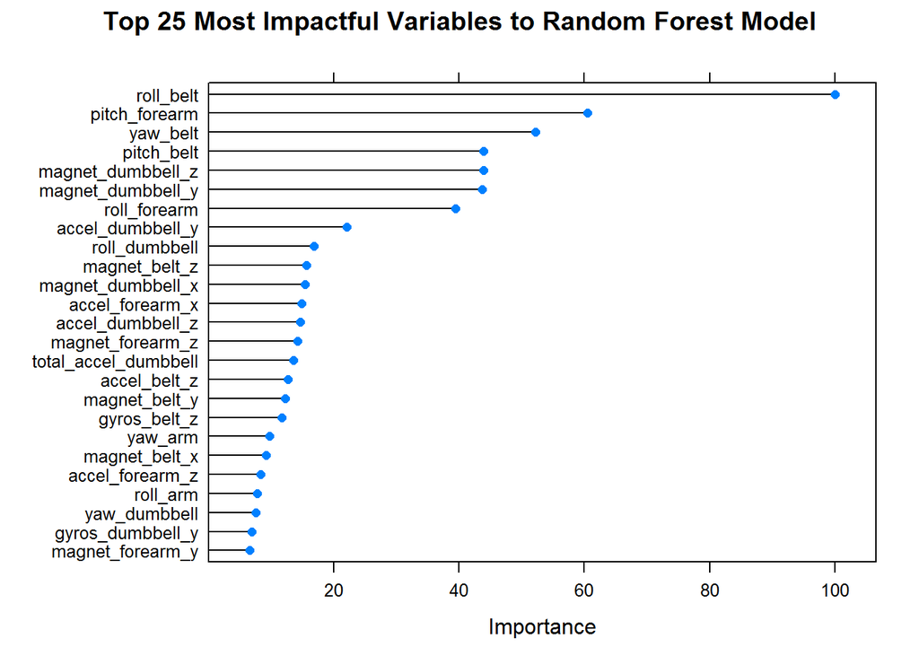

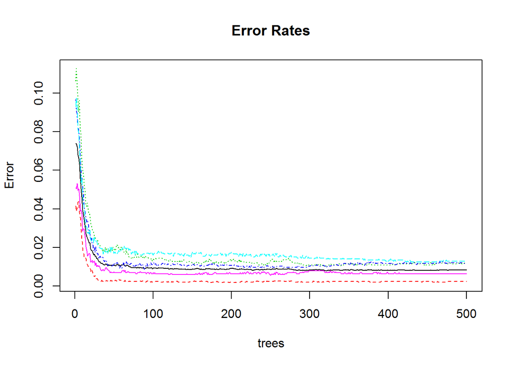

## Final Test

For the final step of the project, after the decision was made to use the random forest model for predicting, the model was run against the testing data

```r
test <- predict(rfmod, newdata=testing)
test
```

```
##  [1] B A B A A E D B A A B C B A E E A B B B
## Levels: A B C D E
```

## References

1. Velloso, E.; Bulling, A.; Gellersen, H.; Ugulino, W.; Fuks, H. Qualitative Activity Recognition of Weight Lifting Exercises. Proceedings of 4th International Conference in Cooperation with SIGCHI (Augmented Human ’13) . Stuttgart, Germany: ACM SIGCHI, 2013. Read more: http://groupware.les.inf.puc-rio.br/har#ixzz43ag0zkAF